# Assignment 11: Detecting Overfitting and Overfitting Issues

Sean Schilk

4/14/26

## **Assignment Objectives**

- Enhance understanding the procedure of likelihood-based chi-square hypothesis testing .
- Implement the procedures for detecting overfitting/underfitting issues in practical applications.

## **Policies of Using AI Tools**

**Policy on AI Tool Use**: Please adhere to the AI tool policy specified in the course syllabus. The direct copying of AI-generated content is strictly prohibited. All submitted work must reflect your own understanding; where external tools are consulted, content must be thoroughly rephrased and synthesized in your own words.

**Code Inclusion Requirement**: Any code included in your essay must be properly commented to explain the purpose and/or expected output of key code lines. Submitting AI-generated code without meaningful, student-added comments will not be accepted.

## Testing Overfitting/Underfitting

In Machine Learning and Statistics, overfitting occurs when a model is too complex and learns noise, leading to poor performance on new data, while underfitting happens when a model is too simple to capture important patterns, resulting in high errors overall; both issues are explained by the Bias–Variance Tradeoff and can cause unreliable predictions in real-world applications.

The probability density function (PDF) of the Weibull distribution is:

$$f(t; \lambda, \beta) = \frac{\beta}{\lambda} \left( \frac{t}{\lambda}
\right)^{\beta-1} \exp\left[ -\left( \frac{t}{\lambda} \right)^\beta
\right], \quad t \ge 0$$
where $\lambda > 0$ is the scale parameter (characteristic life) and $\beta > 0$ is the shape parameter.

When $\beta = 1$, the Weibull PDF simplifies to the exponential PDF:

$$f(t; \lambda) = \frac{1}{\lambda} \exp\left( -\frac{t}{\lambda} \right)$$
with constant hazard rate $h(t) = 1/\lambda$.

**This assignment focuses on performing a hypothesis test for the shape parameter ($\beta$) of the Weibull distribution within a reliability mode**

$$\begin{align}
H_0&: \beta = 1 \quad \text{(Exponential model, simpler)} \\
H_1&: \beta \neq 1 \quad \text{(Weibull model, more complex)}
\end{align}$$

## **Question: Reliability Application**

A mid-sized manufacturing company producing industrial conveyor systems began experiencing unexpected downtime in one of its distribution facilities, prompting concern about the reliability of a newly sourced batch of ball bearings used in the motor assemblies. These bearings, supplied by a vendor adopting cost-saving production methods, were installed across multiple units operating under continuous load conditions. After several months, maintenance logs revealed a pattern of increasing failures, with components lasting anywhere from a few dozen to over 150 hours before breakdown. To investigate, the engineering team collected time-to-failure data from 50 identical bearings and conducted a Weibull analysis within the framework of Reliability Engineering. The 50 time-to-failure (survival time) are:

```r
data <- c(12.4, 18.7, 25.3, 30.1, 33.5, 35.2, 38.9, 40.3, 42.7, 45.1, 47.6, 49.8, 52.4, 55.0,
57.3, 60.2, 62.8, 65.1, 67.9, 70.5, 72.3, 75.6, 78.2, 80.9, 83.4, 85.7, 88.1, 90.6,
93.2, 95.8, 98.4, 101.0, 104.5, 107.3, 110.6, 113.2, 116.8, 120.1, 123.7, 127.4,
130.9, 134.5, 138.2, 142.0, 146.3, 150.7, 155.2, 160.8, 168.4, 175.9)
```

This assignment focuses on hypothesis $H_0: \beta = 1$ (exponential) against $H_1: \beta \neq 1$ (Weibull). This framework detects overfitting (fitting a Weibull when exponential is true) and underfitting (fitting exponential when Weibull with $\beta \neq 1$ is true).

a). Find the MLE of the Weibull parameters $\lambda$ (scale) and $\beta$ (shape), denoted by $\hat{\lambda}$ and $\hat{\beta}$, respectively, using the `optim()` procedure. [*Hint: You should provide explicit expressions for the log-likelihood and gradient functions of the Weibull distribution parameters.*]

```r
###
# **Negative** log-likelihood function for Weibull distribution
log_likelihood <- function(params, data) {
  k <- params[1]       # shape parameter
  lambda <- params[2]  # scale parameter

  # Ensure parameters are positive
  if (k <= 0 || lambda <= 0) {
    return(1e10)  # Return large value for invalid parameters
  }

  n <- length(data)
  log_lik <- n * log(k) - n * k * log(lambda) +
    (k - 1) * sum(log(data)) - sum((data / lambda)^k)

  return(log_lik)  # Return log-likelihood! NOT the negative log-likelihood
}
###
###
# Gradient of **negative** log-likelihood function
log_likelihood_gradient <- function(params, data) {
  k <- params[1]       # shape parameter
  lambda <- params[2]  # scale parameter

  n <- length(data)

  # Partial derivatives
  dk <- n/k - n * log(lambda) + sum(log(data)) -
        sum(log(data/lambda) * (data/lambda)^k)

  dlambda <-  (k/lambda)*(sum((data/lambda)^k) -n)

  return(c(dk, dlambda))  # Gradient of log-likelihood, NOT the negative scores
}
# Finding Initial Values
## It is critical to select appropriate initial values to
## ensure fast convergence. In general, we can use whatever
## methods (such as MME) that are available to get appropriate
## initial values

# Initial parameter estimates (method of moments)

initial_k <- (sd(data)/mean(data))^(-1.086)

initial_lambda <- mean(data)/gamma(1 + 1/initial_k)

####
# MLE using optim() with gradient
result <- optim(
  par = c(initial_k,initial_lambda),
  fn = log_likelihood,
  gr = log_likelihood_gradient,
  data = data,
  method = "L-BFGS-B",         # BFGS can use gradient information L-BFGS-B
  hessian = TRUE,          # this is the observed Hessian matrix
  control = list(maxit = 1000,
                 fnscale  = -1,
                 trace = FALSE,
                 abstol = 1e-8)
)
##
result
```

```
$par
[1]  2.20600 99.02106

$value
[1] -256.4198

$counts
function gradient
      12       12

$convergence
[1] 0

$message
[1] "CONVERGENCE: REL_REDUCTION_OF_F <= FACTR*EPSMCH"

$hessian
            [,1]        [,2]
[1,] -17.5907836  0.20543260
[2,]   0.2054326 -0.02481507
```

```r
fitdist(data, "weibull", method = "mle", calcvcov=TRUE) # to check
```

```
Fitting of the distribution ' weibull ' by maximum likelihood
Parameters:
       estimate Std. Error
shape  2.205683  0.2508329
scale 99.019369  6.6799243
```

b). Find the MLE of the exponential parameter $\lambda$ (scale), denoted by $\hat{\lambda}$, using any procedure. [*Hint: You should provide explicit expressions for the log-likelihood and gradient functions of the exponential distribution parameters.*]

```r
# Log-likelihood for Exponential
exp_loglik <- function(lambda, data) {
  if (lambda <= 0) return(1e10)
  n <- length(data)
  log_lik <- -n * log(lambda) - sum(data) / lambda
  return(log_lik)
}

#score functions
exp_gradient <- function(lambda, data) {
  if (lambda <= 0) return(NA)

  n <- length(data)
  sum_x <- sum(data)

  grad <- -n / lambda + sum_x / (lambda^2)
  return(grad)
}

mle_result <- optim(
  par = mean(data),
  fn = exp_loglik,
  gr = exp_gradient,
  data = data,
  method = "L-BFGS-B",         # BFGS can use gradient information L-BFGS-B
  hessian = TRUE,          # this is the observed Hessian matrix
  control = list(maxit = 1000,
                 fnscale  = -1,
                 trace = FALSE,
                 abstol = 1e-8)
)
##
mle_result
```

```
$par
[1] 87.61

$value
[1] -273.6448

$counts
function gradient
       1        1

$convergence
[1] 0

$message
[1] "CONVERGENCE: NORM OF PROJECTED GRADIENT <= PGTOL"

$hessian
             [,1]
[1,] -0.006514223
```

```r
fitdist(data, "exp", method = "mle", calcvcov=TRUE) # to check
```

```
Fitting of the distribution ' exp ' by maximum likelihood
Parameters:
       estimate  Std. Error
rate 0.01141422 0.001601712
```

```r
rate_hat <-  1/0.01141422 # so we're good
```

c). Perform the likelihood ratio $\chi^2$ test on $\beta = 1$. What is the p-value? [*Hint: Use the results in a) and b)*.]

```r
LR = -2*(exp_loglik(mle_result$par,data) - log_likelihood(result$par,data))
LR
```

```
[1] 34.44995
```

```r
pval <- 1 - pchisq(LR, df = 1)
pval
```

```
[1] 4.373531e-09
```

The p-value is 4.3735308^{-9}. The p-value is nearly zero, leading to the rejection of the null hypothesis.

d). Perform the Wald $\chi^2$ on the same hypothesis $\beta = 1$. What is the p-value? [*Hint: You need to find the observed Fisher information matrix (i.e., the negative Hessian matrix from `optim()`) based on the Weibull distribution. The inverse of the observed Hessian matrix is the covariance matrix*.]

```r
varcov <- solve(-result$hessian)
beta.hat  <- result$par[1]     # based on the unrestricted likelihood estimation
se.beta <- sqrt(varcov[1, 1])  # the square root of the top-left diagonal value
W <- (beta.hat - 1)^2/se.beta^2   # Wald test statistic
##
pval.W <- 1 - pchisq(W, df = 1)
pval.W
```

```
[1] 1.529033e-06
```

The p-value is smaller than 0.05 implying the rejection of the null hypothesis.

e). Write a summary of the above analyses to address the following:

- Whether the two tests generated the same results.
- Which model is recommended for the data.
- Draw the density curve based on the MLE(s) of the parameter(s) and describe the distribution of the time-to-failure.

Both analyses led to a rejection of the null, so they had the same results. With a sample size of 50, which is quite small, I would recommend the Likelihood Ratio Test.

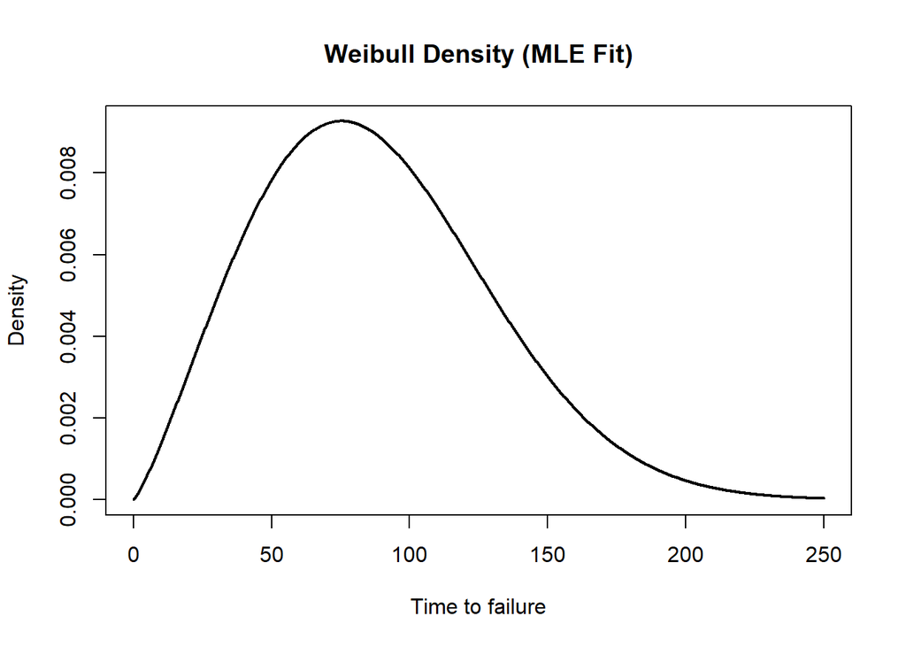

```r
beta <- result$par[1]
lambda <- result$par[2]

n <- seq(0, 250, length.out = 1000)

density <- dweibull(n, shape = beta, scale = lambda)

plot(n, density, type = "l", lwd = 2,
     main = "Weibull Density (MLE Fit)",
     xlab = "Time to failure",
     ylab = "Density")
```

The peak of the density curve was around 70 hours, so I would say most components time to failure was about that time. The curve is roughly bell shaped, with right skew, classic signs of a weibull dist.